# Bioconductor infrastructures

Juan R Gonzalez

Bioinformatics Research Group in Epidemiology, Barcelona Institute for Global Health, Spain

juanr.gonzalez@isglobal.org

July, 2019

#### Abstract

Brief introduction to Bioconductor, `GRanges` objects and a global overview of main Bioconductor data structures (`ExpressionSet` and `SummarizedExperiments`).

# 1 Gettig started

This document can be reproduced by using the R code and the data (for illustrating purposes and for the excersises) that are available here: https://github.com/isglobal-brge/post_omic

# 2 Global description

It is assumed that people who read this material are familiar with omic association analyses (GWAS, gene expression, methylation, RNA-seq, …). There are two other files illustrating how to provide biological insights of those significant features obtained in these association studies (SNPs, genes, CpGs, genomic regions, …). Here (Session 1) we provide a global overview about Bioconductor, some of the infrastructures used to encapsulate omic data and the use of `GenomicRanges` which helps to manipulate genomic annotations when analyzing high-throughput sequencing data. Session 2 illustrates how to visualize significant results (circos plots and genomic tracks) along with information from omic annotations (ENCODE, GTEx, GWAS catalog, …). Finally, Session 3 will show how to assess whether our hits are significantly enriched in those annotated databases.

We do not aim to give a global overview of existing Bioconductor packages to perform visualization, annotations or enrichment analyses since they are very well detailed in their related vignettes. Our goal is to provide the main details to reproduce real analyses that appear in most of the papers which analyze omic data.

Association analyses can be performed by using different programs. Here you can find a solution under R/Bioconductor infrastructure: https://isglobal-brge.github.io/book_omic_association/

[figure not shown]

Omic association analyses

# 3 Introduction

This lecture offers a summary of two data structures (`ExpressionSet` and `SummarizedExperiments`) that are implemented in Bioconductor for dealing with transcriptomic or epigenomic data. Omic data are typically composed of three datasets: one containing the actual high-dimensional data of omic variables per individuals, annotation data that specifies the characteristics of the variables and phenotypic information that encodes the subject’s traits of interest, covariates and sampling characteristics. For instance, transcriptomic data can be stored in a `ExpressionSet` object, which is a data structure that contains the transcription values of individuals at each transcription probe, the genomic information for the transcription probes and the phenotypes of the individuals. Specific data is accessed, processed and analyzed with specific functions from diverse packages, conceived as methods acting on the `ExpressionSet` objects.

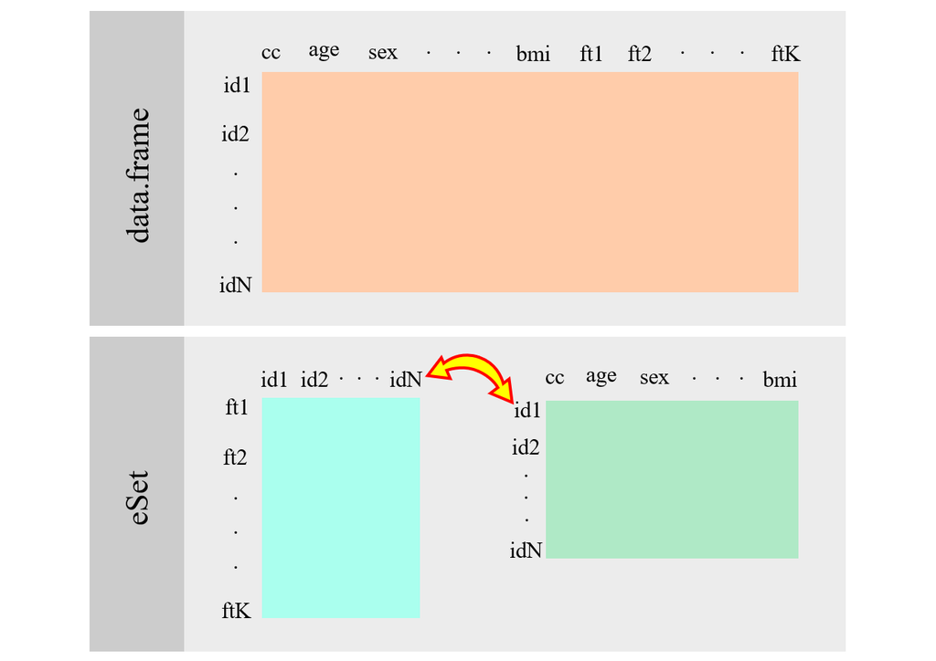

Data in Bioconductor

# 4 Bioconductor

- [Bioconductor](https://bioconductor.org/)’s goal: Analysis and comprehension of high-throughput genomic data
- Statistical analysis: large data, technological artifacts, designed experiments; rigorous
- Comprehension: biological context, visualization, reproducibility
- High-throughput
  - Sequencing: RNASeq, ChIPSeq, variants, copy number, …
  - Microarrays: expression, SNP, …
  - Flow cytometry, proteomics, images, …

## 4.1 Packages, vignettes, work flows, …

- 1649 software packages (Jan’19); also…
  - ‘Annotation’ packages – static data bases of identifier maps,gene models, pathways, etc; e.g., `TxDb.Hsapiens.UCSC.hg19.knownGene`
  - ’Experiment packages – data sets used to illustrate software functionality, e.g., `airway`
- Discover and navigate via `biocViews`
- Package ‘landing page’
  - Title, author / maintainer, short description, citation, installation instructions, …, download statistics
- All user-visible functions have help pages, most with runnable examples

## 4.2 Vignettes

- ‘Vignettes’ an important feature in Bioconductor – narrative documents illustrating how to use the package, with integrated code
- ‘Release’ (every six months) and ‘devel’ branches
- [Support site](https://support.bioconductor.org); [videos](https://www.youtube.com/user/bioconductor), [recent courses](https://bioconductor.org/help/course-materials/)

## 4.3 Bioconductor packages installation

```r
install.packages("BiocManager")
library(BiocManager)
install(c("DESeq2", "org.Hs.eg.db"))

# or

BiocManager::install("DESeq2")
```

Remember that Github packages can be install by

```r
install.packages("devtools")
devtools::install_github("isglobal-brge/SNPassoc")
```

Once installed, the package can be loaded into an R session

```r
library(GenomicRanges)
```

and the help system queried interactively, as outlined above:

```r
help(package="GenomicRanges")
vignette(package="GenomicRanges")
vignette(package="GenomicRanges",
         "GenomicRangesHOWTOs")
?GRanges
```

# 5 `ExpressionSet` objects

- `ExpressionSet` was one of the first implementations of Bioconductor to manage experiments.
- It is discouraged in Bioconductor’s guidelines for the development of current and future packages
- However, most publicly available data is available in this structure while future packages are still required to be able to upload and operate with it.
- The rows of data are features and columns are subjects.
- Information is coordinated across the object’s slots. For instance, subsetting samples in the assay matrix automatically subsets them in the phenotype metadata.

GEO repository (https://www.ncbi.nlm.nih.gov/geo/) contains thousands of transcriptomic experiments that are available in `ExpressionSet` format. Data can be loaded into R by:

```r
library(GEOquery)
gse69683 <- getGEO("GSE69683", destdir = ".")
gse69683.expr <- gse69683[[1]]
```

You can directly loaded it into R with:

```r
load("data/GSE69683.Rdata")
```

This is how an `ExpressionSet` looks like:

```r
gse69683.expr
```

```
ExpressionSet (storageMode: lockedEnvironment)
assayData: 54715 features, 498 samples
  element names: exprs
protocolData: none
phenoData
  sampleNames: GSM1706836 GSM1706837 ... GSM1707333 (498 total)
  varLabels: title geo_accession ... tissue:ch1 (37 total)
  varMetadata: labelDescription
featureData
  featureNames: 1007_PM_s_at 1053_PM_at ... AFFX-TrpnX-M_at (54715 total)
  fvarLabels: ID GB_ACC ... Gene Ontology Molecular Function (16 total)
  fvarMetadata: Column Description labelDescription
experimentData: use 'experimentData(object)'
  pubMedIds: 27925796
Annotation: GPL13158
```

- `gse69683.expr` is an object of class `ExpressionSet` that has three main slots:
  - Transcriptomic data is stored in the `assayData`
  - Phenotypes (i.e. covariates) are in `phenoData`
  - Probe annotation in `featuredData`.
  - There are three other slots `protocolData`, `experimentData` and `annotation` with other information

Gene expression data can be retrieved by

```r
expr <- exprs(gse69683.expr)
dim(expr)
```

```
[1] 54715   498
```

```r
expr[1:5,1:5]
```

```
             GSM1706836 GSM1706837 GSM1706838 GSM1706839 GSM1706840
1007_PM_s_at       4.58       5.62       4.90       4.33       5.30
1053_PM_at         6.72       6.44       6.75       6.57       6.64
117_PM_at          8.75       8.44       8.26       9.16       9.29
121_PM_at          5.43       4.53       5.04       5.04       4.85
1255_PM_g_at       2.63       2.48       2.54       2.71       2.59
```

Phenotypic data (i.e. covariates) are accesed by

```r
pheno <- phenoData(gse69683.expr)
pheno
```

```
An object of class 'AnnotatedDataFrame'
  sampleNames: GSM1706836 GSM1706837 ... GSM1707333 (498 total)
  varLabels: title geo_accession ... tissue:ch1 (37 total)
  varMetadata: labelDescription
```

```r
colnames(pheno)[1:10]
```

```
 [1] "title"               "geo_accession"       "status"              "submission_date"     "last_update_date"
 [6] "type"                "channel_count"       "source_name_ch1"     "organism_ch1"        "characteristics_ch1"
```

Data are properly organized. So that, we can run any statistical model or method you want

```r
group <- pheno$characteristics_ch1
table(group)
```

```
group
        cohort: Healthy, non-smoking cohort: Moderate asthma, non-smoking   cohort: Severe asthma, non-smoking
                                  87                                   77                                  246
      cohort: Severe asthma, smoking
                                  88
```

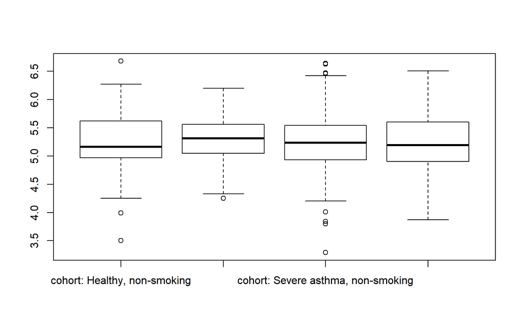

```r
boxplot(expr["1007_PM_s_at",] ~ group)
```

The `fData` function gets the probes’ annotation that will be required to genome data visualization and post-data analysis

```r
probes <- fData(gse69683.expr)
probes[1:5, 1:5]
```

```
                       ID GB_ACC SPOT_ID Species Scientific Name Annotation Date
1007_PM_s_at 1007_PM_s_at U48705      NA            Homo sapiens    Aug 20, 2010
1053_PM_at     1053_PM_at M87338      NA            Homo sapiens    Aug 20, 2010
117_PM_at       117_PM_at X51757      NA            Homo sapiens    Aug 20, 2010
121_PM_at       121_PM_at X69699      NA            Homo sapiens    Aug 20, 2010
1255_PM_g_at 1255_PM_g_at L36861      NA            Homo sapiens    Aug 20, 2010
```

Subsetting acts as in any other R object. Let us assume we want to select only healthy individuals

```r
sel <- "cohort: Healthy, non-smoking"
mask <- gse69683.expr$characteristics_ch1%in%sel
gse <- gse69683.expr[ , mask]
gse
```

```
ExpressionSet (storageMode: lockedEnvironment)
assayData: 54715 features, 87 samples
  element names: exprs
protocolData: none
phenoData
  sampleNames: GSM1706838 GSM1706840 ... GSM1707332 (87 total)
  varLabels: title geo_accession ... tissue:ch1 (37 total)
  varMetadata: labelDescription
featureData
  featureNames: 1007_PM_s_at 1053_PM_at ... AFFX-TrpnX-M_at (54715 total)
  fvarLabels: ID GB_ACC ... Gene Ontology Molecular Function (16 total)
  fvarMetadata: Column Description labelDescription
experimentData: use 'experimentData(object)'
  pubMedIds: 27925796
Annotation: GPL13158
```

# 6 `GenomicRanges`

- Aims aims to represent and manipulate the genomic annotation of molecular data under a reference genome.
- It contains functions to select specific regions and perform operations with them
- Are important to annotate and manipulate genomic, transcriptomic and epigenomic data.
- In particular, they are used in conjunction with `RangedSummarizedExperiment` which is an extension of `ExpressionSet`.

The **annotation** data refers to the characteristics of the variables in data. Each variable/feature (SNP, gene, CpG, …) may be given a location in a reference genome that defines a coordinate system: “chromosome id” and “position” along the chromosome. For instance, a position such as chr10:4567-5671 would represent the 4567th to the 5671st base pair on the reference’s chromosome 10.

The main functionalities implemented in the package `GenomicRanges` are methods on `GRanges`. They are created by the function `GRanges`. Minimum requirements are the genomic positions given by the chromosome (argument `seqnames`) and base pair coordinates (argument `ranges`).

```r
library(GenomicRanges)
gr <- GRanges(seqnames=c(rep("chr1", 4), rep("chr2", 4)),
              ranges = IRanges(start = c(1000, 1800, 5300, 7900,
                                         1300, 2100, 3400, 6700),
                               end =c(2200, 3900, 5400, 8100,
                                      2600, 3300, 4460, 6850)),
              strand = rep(c("+", "-"), 4),
              disease = c(rep("Asthma",4), rep("Obesity",4)))
gr
```

```
GRanges object with 8 ranges and 1 metadata column:
      seqnames    ranges strand |     disease
         <Rle> <IRanges>  <Rle> | <character>
  [1]     chr1 1000-2200      + |      Asthma
  [2]     chr1 1800-3900      - |      Asthma
  [3]     chr1 5300-5400      + |      Asthma
  [4]     chr1 7900-8100      - |      Asthma
  [5]     chr2 1300-2600      + |     Obesity
  [6]     chr2 2100-3300      - |     Obesity
  [7]     chr2 3400-4460      + |     Obesity
  [8]     chr2 6700-6850      - |     Obesity
  -------
  seqinfo: 2 sequences from an unspecified genome; no seqlengths
```

`GRanges` objects can be large and there are several functions to access data in different ways.

- Access to a given range

```r
gr[1]
```

```
GRanges object with 1 range and 1 metadata column:
      seqnames    ranges strand |     disease
         <Rle> <IRanges>  <Rle> | <character>
  [1]     chr1 1000-2200      + |      Asthma
  -------
  seqinfo: 2 sequences from an unspecified genome; no seqlengths
```

- `seqnames` extract the chromosomes:

```r
seqnames(gr)
```

```
factor-Rle of length 8 with 2 runs
  Lengths:    4    4
  Values : chr1 chr2
Levels(2): chr1 chr2
```

```r
seqnames(gr)[1] <- "chr2"
gr
```

```
GRanges object with 8 ranges and 1 metadata column:
      seqnames    ranges strand |     disease
         <Rle> <IRanges>  <Rle> | <character>
  [1]     chr2 1000-2200      + |      Asthma
  [2]     chr1 1800-3900      - |      Asthma
  [3]     chr1 5300-5400      + |      Asthma
  [4]     chr1 7900-8100      - |      Asthma
  [5]     chr2 1300-2600      + |     Obesity
  [6]     chr2 2100-3300      - |     Obesity
  [7]     chr2 3400-4460      + |     Obesity
  [8]     chr2 6700-6850      - |     Obesity
  -------
  seqinfo: 2 sequences from an unspecified genome; no seqlengths
```

- Add information:

```r
gr$gene_id <- paste0("Gene", 1:8)
gr
```

```
GRanges object with 8 ranges and 2 metadata columns:
      seqnames    ranges strand |     disease     gene_id
         <Rle> <IRanges>  <Rle> | <character> <character>
  [1]     chr2 1000-2200      + |      Asthma       Gene1
  [2]     chr1 1800-3900      - |      Asthma       Gene2
  [3]     chr1 5300-5400      + |      Asthma       Gene3
  [4]     chr1 7900-8100      - |      Asthma       Gene4
  [5]     chr2 1300-2600      + |     Obesity       Gene5
  [6]     chr2 2100-3300      - |     Obesity       Gene6
  [7]     chr2 3400-4460      + |     Obesity       Gene7
  [8]     chr2 6700-6850      - |     Obesity       Gene8
  -------
  seqinfo: 2 sequences from an unspecified genome; no seqlengths
```

We can also have acces to extra columns in the `GRanges` object as following:

```r
mcols(gr)
```

```
DataFrame with 8 rows and 2 columns
      disease     gene_id
  <character> <character>
1      Asthma       Gene1
2      Asthma       Gene2
3      Asthma       Gene3
4      Asthma       Gene4
5     Obesity       Gene5
6     Obesity       Gene6
7     Obesity       Gene7
8     Obesity       Gene8
```

```r
table(mcols(gr)$disease)
```

```
 Asthma Obesity
      4       4
```

`GenomicRanges` package provides different methods to perform arithmetic with the ranges, see `?GRanges` or [here](https://bioconductor.org/help/course-materials/2014/SeattleFeb2014/) for a detailed list of methods and operations.

For instance, with `shift` an interval is moved a given base-pair distance and with `flank` the interval is stretched

```r
#shift: move all intervals 10 base pair towards the end
shift(gr, 10)
```

```
GRanges object with 8 ranges and 2 metadata columns:
      seqnames    ranges strand |     disease     gene_id
         <Rle> <IRanges>  <Rle> | <character> <character>
  [1]     chr2 1010-2210      + |      Asthma       Gene1
  [2]     chr1 1810-3910      - |      Asthma       Gene2
  [3]     chr1 5310-5410      + |      Asthma       Gene3
  [4]     chr1 7910-8110      - |      Asthma       Gene4
  [5]     chr2 1310-2610      + |     Obesity       Gene5
  [6]     chr2 2110-3310      - |     Obesity       Gene6
  [7]     chr2 3410-4470      + |     Obesity       Gene7
  [8]     chr2 6710-6860      - |     Obesity       Gene8
  -------
  seqinfo: 2 sequences from an unspecified genome; no seqlengths
```

```r
#shift: move each intervals individually
shift(gr, seq(10,100, length=8))
```

```
GRanges object with 8 ranges and 2 metadata columns:
      seqnames    ranges strand |     disease     gene_id
         <Rle> <IRanges>  <Rle> | <character> <character>
  [1]     chr2 1010-2210      + |      Asthma       Gene1
  [2]     chr1 1822-3922      - |      Asthma       Gene2
  [3]     chr1 5335-5435      + |      Asthma       Gene3
  [4]     chr1 7948-8148      - |      Asthma       Gene4
  [5]     chr2 1361-2661      + |     Obesity       Gene5
  [6]     chr2 2174-3374      - |     Obesity       Gene6
  [7]     chr2 3487-4547      + |     Obesity       Gene7
  [8]     chr2 6800-6950      - |     Obesity       Gene8
  -------
  seqinfo: 2 sequences from an unspecified genome; no seqlengths
```

```r
#flank:  recover regions next to the input set.
#        For a 50 base stretch upstream (negative value for
#        downstream)
flank(gr, 50)
```

```
GRanges object with 8 ranges and 2 metadata columns:
      seqnames    ranges strand |     disease     gene_id
         <Rle> <IRanges>  <Rle> | <character> <character>
  [1]     chr2   950-999      + |      Asthma       Gene1
  [2]     chr1 3901-3950      - |      Asthma       Gene2
  [3]     chr1 5250-5299      + |      Asthma       Gene3
  [4]     chr1 8101-8150      - |      Asthma       Gene4
  [5]     chr2 1250-1299      + |     Obesity       Gene5
  [6]     chr2 3301-3350      - |     Obesity       Gene6
  [7]     chr2 3350-3399      + |     Obesity       Gene7
  [8]     chr2 6851-6900      - |     Obesity       Gene8
  -------
  seqinfo: 2 sequences from an unspecified genome; no seqlengths
```

It is also possible to perform operations between two different `GRanges` objects. For instance, one may be interested in knowing the intervals that overlap with a targeted region:

```r
target <- GRanges(seqnames="chr1",
                  range=IRanges(start=1200, 4000))
target
```

```
GRanges object with 1 range and 0 metadata columns:
      seqnames    ranges strand
         <Rle> <IRanges>  <Rle>
  [1]     chr1 1200-4000      *
  -------
  seqinfo: 1 sequence from an unspecified genome; no seqlengths
```

```r
gr.ov <- findOverlaps(target, gr)
gr.ov
```

```
Hits object with 1 hit and 0 metadata columns:
      queryHits subjectHits
      <integer>   <integer>
  [1]         1           2
  -------
  queryLength: 1 / subjectLength: 8
```

# 7 `SummarizedExperiment`

- It is an extension of `ExpressionSet` objects.
- The `SummarizedExperiment` package contains two classes: `SummarizedExperiment` and `RangedSummarizedExperiment`.
- The fundamental difference between the two classes is that the rows of a `RangedSummarizedExperiment` object represent genomic ranges of interest instead of a DataFrame of feature. The ranges are accesses with `rowRanges()`

[figure not shown]

SummarizedExperiment

`airway` package contains an example dataset from an RNA-Seq experiment of read counts per gene for airway smooth muscles. These data are stored in a `RangedSummarizedExperiment` object which contains 8 different experimental and assays 64,102 gene transcripts.

```r
library(SummarizedExperiment)
data(airway, package="airway")
se <- airway
se
```

```
class: RangedSummarizedExperiment
dim: 64102 8
metadata(1): ''
assays(1): counts
rownames(64102): ENSG00000000003 ENSG00000000005 ... LRG_98 LRG_99
rowData names(0):
colnames(8): SRR1039508 SRR1039509 ... SRR1039520 SRR1039521
colData names(9): SampleName cell ... Sample BioSample
```

Experiment data is accesed with `assay()`:

```r
names(assays(se))
```

```
[1] "counts"
```

```r
gene.dat <- assays(se)$counts
gene.dat[1:5, 1:5]
```

```
                SRR1039508 SRR1039509 SRR1039512 SRR1039513 SRR1039516
ENSG00000000003        679        448        873        408       1138
ENSG00000000005          0          0          0          0          0
ENSG00000000419        467        515        621        365        587
ENSG00000000457        260        211        263        164        245
ENSG00000000460         60         55         40         35         78
```

Phenotypic data is accesed with `colData()`:

```r
colData(se)
```

```
DataFrame with 8 rows and 9 columns
           SampleName     cell      dex    albut        Run avgLength Experiment    Sample    BioSample
             <factor> <factor> <factor> <factor>   <factor> <integer>   <factor>  <factor>     <factor>
SRR1039508 GSM1275862   N61311    untrt    untrt SRR1039508       126  SRX384345 SRS508568 SAMN02422669
SRR1039509 GSM1275863   N61311      trt    untrt SRR1039509       126  SRX384346 SRS508567 SAMN02422675
SRR1039512 GSM1275866  N052611    untrt    untrt SRR1039512       126  SRX384349 SRS508571 SAMN02422678
SRR1039513 GSM1275867  N052611      trt    untrt SRR1039513        87  SRX384350 SRS508572 SAMN02422670
SRR1039516 GSM1275870  N080611    untrt    untrt SRR1039516       120  SRX384353 SRS508575 SAMN02422682
SRR1039517 GSM1275871  N080611      trt    untrt SRR1039517       126  SRX384354 SRS508576 SAMN02422673
SRR1039520 GSM1275874  N061011    untrt    untrt SRR1039520       101  SRX384357 SRS508579 SAMN02422683
SRR1039521 GSM1275875  N061011      trt    untrt SRR1039521        98  SRX384358 SRS508580 SAMN02422677
```

Subset for only those samples treated with dexamethasone

```r
se[, se$dex == "trt"]
```

```
class: RangedSummarizedExperiment
dim: 64102 4
metadata(1): ''
assays(1): counts
rownames(64102): ENSG00000000003 ENSG00000000005 ... LRG_98 LRG_99
rowData names(0):
colnames(4): SRR1039509 SRR1039513 SRR1039517 SRR1039521
colData names(9): SampleName cell ... Sample BioSample
```

We can also subset a `SummarizedExperiment` by a given interval or genomic region

```r
roi <- GRanges(seqnames="chr1", ranges=100000:1100000)
# or
roi <- GRanges(seqnames="1", IRanges(start=100000,
                                        end=1100000))
se.roi <- subsetByOverlaps(se, roi)
se.roi
```

```
class: RangedSummarizedExperiment
dim: 74 8
metadata(1): ''
assays(1): counts
rownames(74): ENSG00000131591 ENSG00000177757 ... ENSG00000272512 ENSG00000273443
rowData names(0):
colnames(8): SRR1039508 SRR1039509 ... SRR1039520 SRR1039521
colData names(9): SampleName cell ... Sample BioSample
```

It is worth to notice that the chromosome is accessed by using `seqnames="1"` instead of `seqnames="chr1"` since they are annotated in the [NCBI](https://www.ncbi.nlm.nih.gov/) or [Ensembl](https://www.ensembl.org/index.html) style:

```r
seqlevelsStyle(se)
```

```
[1] "NCBI"    "Ensembl"
```

NOTE: `seqnames="chr1"` corresponds to [UCSC](https://genome.ucsc.edu/) style

**EXERCISE**: [Recount2](https://jhubiostatistics.shinyapps.io/recount/) provides data for different RNA-seq experiments. These includes data from GTEx or TCGA projects. We have donwloaded a subset of data corresponding to breast cancer and created a variable called `er` which encodes the estrogen receptor status (Negative and Positive). The `SummarizedExperiment` object is called `breast` and is available in the file `data_exercises/breast_tcga.Rdata`. Load the data into R and answer the next questions

1. How many samples are in the `SummarizedExperiment` object?
2. And how many genes?
3. Which is the number of samples with positive estrogen receptor status (variable `er`)?
4. Subset the individuals having Negative strogen receptor status and draw a boxplot of the first gene.
5. Create a `SummarizedExperiment` object of the genomic region chr6:151.2-151.8Mb. How many genes are in that region? How many of them are annotated? That is, how many of them have a gene symbol name (HINT: use `rowRanges()` function and remember that `mcols()` function is used to get acccess to columns in a `GRanges` object) ?